# Final Project - Greenspace and Wellbeing

Wylie Hampson

11/28/2021

### Import the data

```r
data_full <- read_csv(here("data", "greenspace_data.csv")) %>%
  clean_names()
```

### I am interested in particular how having windows in their bedrooms affects college and graduate students. So from this data set I will filter out only the people who are 30 and younger, since that will more similarly represent students.

```r
data <- data_full %>%
  filter(age <= 30)
```

### Next, I’ll make a well-being column that adds up the values for life satisfaction, self-esteem, and subjective happiness. Then, subtracts values from the depression and anxiety column, and the lonliness column. This will give one value for a persons overall well being. I do this in the full data set as well so that I can compare them later.

```r
data <- data %>%
  mutate(well_being = (life_satisfaction + self_esteem + subjective_happiness) - (depression_and_anxiety + loneliness))

data_full <- data_full %>%
  mutate(well_being = (life_satisfaction + self_esteem + subjective_happiness) - (depression_and_anxiety + loneliness))
```

### Plot a quick histogram of the well-being values. It looks like a fairly normal distribution.

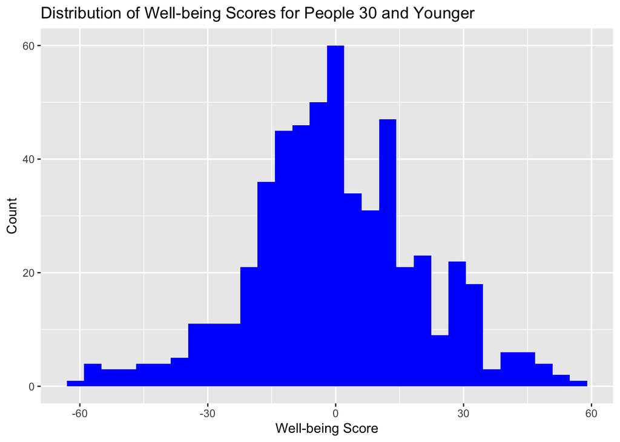

```r
ggplot(data = data, aes(x = well_being)) +
  geom_histogram(fill = "blue") +
  labs(x = "Well-being Score",
       y = "Count",
       title = "Distribution of Well-being Scores for People 30 and Younger")
```

### Make a box plot of well-being versus whether or not a person has a window with a view of nature in their room.

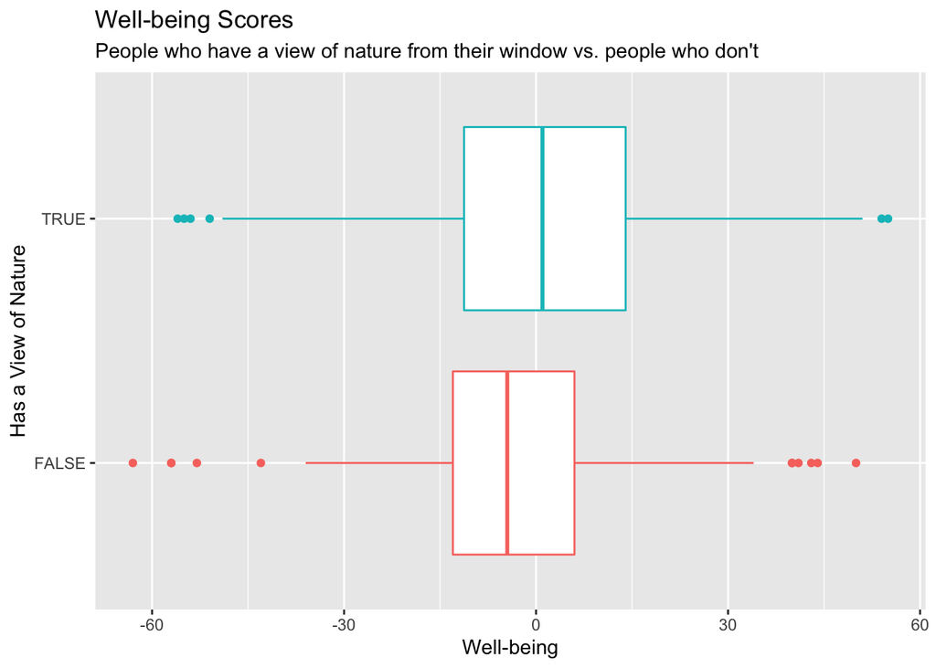

```r
data <- data %>%
  mutate(nature_view = as.logical(nature_view))

ggplot(data = data, aes(x = well_being, y = nature_view)) +
  geom_boxplot(aes(color = nature_view)) +
  labs(x = "Well-being",
       y = "Has a View of Nature",
       title = "Well-being Scores",
       subtitle = "People who have a view of nature from their window vs. people who don't") +
  theme(legend.position = "none")
```

### Here I’m finding the z-score, standard error, point estimate, means values, and p-value by hand.

```r
# Mean values for window with a view of nature vs. no view of nature.
mu_window <- data %>%
  filter(nature_view == TRUE) %>%
  summarize(mean(well_being))

mu_no_window <- data %>%
  filter(nature_view == FALSE) %>%
  summarize(mean(well_being))

# Point Estimate
point_est <- as.numeric(mu_window - mu_no_window)
```

```r
# Counts and standard deviations for each group
n_window = data %>% filter(nature_view == TRUE) %>% count()
n_no_window = data %>% filter(nature_view == FALSE) %>% count()
sd_window = data %>% filter(nature_view == TRUE) %>% summarize(sd(well_being, na.rm = TRUE))
sd_no_window = data %>% filter(nature_view == FALSE) %>% summarize(sd(well_being, na.rm = TRUE))

# Do the same thing with the full dataset to compare later.
n_window_full = data_full %>% filter(nature_view == TRUE) %>% count()
n_no_window_full = data_full %>% filter(nature_view == FALSE) %>% count()
sd_window_full = data_full %>% filter(nature_view == TRUE) %>% summarize(sd(well_being, na.rm = TRUE))
sd_no_window_full = data_full %>% filter(nature_view == FALSE) %>% summarize(sd(well_being, na.rm = TRUE))

# Standard Error
SE = as.numeric(sqrt(sd_window ^ 2 / n_window + sd_no_window ^ 2 / n_no_window))
print(SE)
```

```
## [1] 1.920994
```

```r
# z-score
zscore <- point_est / SE

# p-value
p_val <- 2 * pnorm(point_est, mean = 0, sd = SE, lower.tail = FALSE)
p_val
```

```
## [1] 0.03945731
```

### Now I’m finding all of the same things as above, but with a t-test. I get very similar results, which is a good thing!

```r
t.test(well_being ~ nature_view, data = data)
```

```
##
##  Welch Two Sample t-test
##
## data:  well_being by nature_view
## t = -2.0594, df = 267.27, p-value = 0.04043
## alternative hypothesis: true difference in means between group FALSE and group TRUE is not equal to 0
## 95 percent confidence interval:
##  -7.7382736 -0.1738615
## sample estimates:
## mean in group FALSE  mean in group TRUE
##           -2.890411            1.065657
```

### Now let’s see if going outside interacts as well.

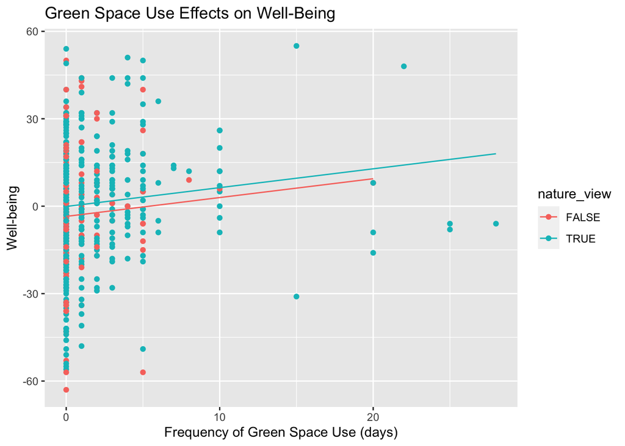

```r
mod <- lm(well_being ~ greenspace_use_frequency + nature_view, data = data)

ggplot(data = data, aes(x = greenspace_use_frequency, y = well_being, color = nature_view)) +
  geom_point() +
  geom_line(data = mod, aes(y = .fitted, color = nature_view)) +
  labs(x = "Frequency of Green Space Use (days)",
       y = "Well-being",
       title = "Green Space Use Effects on Well-Being")
```

### Here is what the parallel slope model looks like when all of the data is plotted instead of just people under 30.

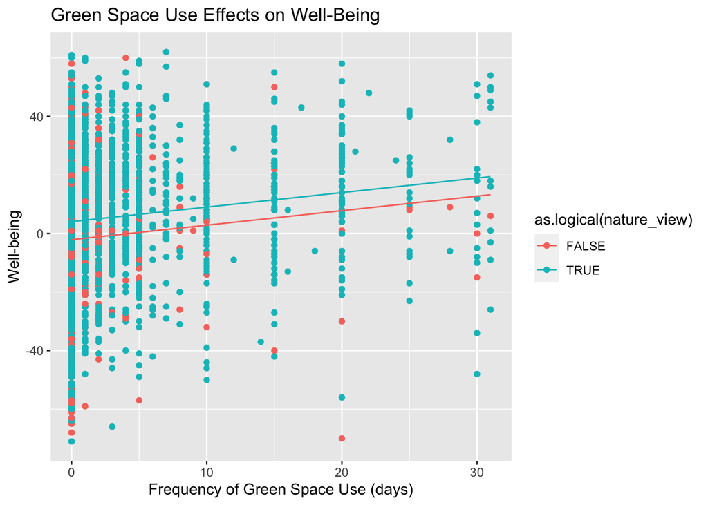

```r
mod_full <- lm(well_being ~ greenspace_use_frequency + nature_view, data = data_full)

ggplot(data = data_full, aes(x = greenspace_use_frequency, y = well_being, color = as.logical(nature_view))) +
  geom_point() +
  geom_line(data = mod_full, aes(y = .fitted, color = as.logical(nature_view))) +
  labs(x = "Frequency of Green Space Use (days)",
       y = "Well-being",
       title = "Green Space Use Effects on Well-Being")
```

### Here is a summary table with all of the coefficents for the parallel slope model for people 30 and younger, as well as the $R^2$ value.

```r
r_squared <- summary(mod)$r.squared

summary(mod) %>%
  xtable() %>%
  knitr::kable()
```

|  | Estimate | Std. Error | t value | Pr(>\|t\|) |
| --- | --- | --- | --- | --- |
| (Intercept) | -3.4969214 | 1.678282 | -2.083632 | 0.0376642 |
| greenspace_use_frequency | 0.6463542 | 0.254572 | 2.538984 | 0.0113975 |
| nature_viewTRUE | 3.4020784 | 1.955656 | 1.739610 | 0.0824984 |

```r
print(paste0("R-squared value = ", r_squared))
```

```
## [1] "R-squared value = 0.0192690554741357"
```